# Análisis de Componentes Principales (PCA)

Sonia Tarazona

2026-02-27

```r
library(knitr)
knitr::opts_chunk$set(echo = TRUE)
## Para instalar una librería de Github
# install.packages("devtools")
# devtools::install_github("BiostatOmics/PLSandO")
library(PLSandO)
library(gridExtra)
```

# 1 Lectura y preparación de datos

En esta práctica guiada utilizaremos los datos de ejemplo de cereales. Cargamos los datos y generamos la tabla auxiliar de variables incluyendo su tipo. Añadiremos una columna que indique con un 1 si la variable describe el contenido nutricional de los cereales (importante para los análisis que haremos) o 0, si aporta otro tipo de información.

```r
cereals = read.csv("archivos de datos/Cereals.csv", row.names = 1, as.is = TRUE)
descCere = data.frame("variable" = colnames(cereals),
                      "tipo" = c("categorical", "categorical",
                                 rep("numerical", 9), "categorical",
                                 rep("numerical", 3)),
                      "nutri" = c(rep(0,2), rep(1,9), rep(0,3), 1),
                      stringsAsFactors = FALSE)
rownames(descCere) = descCere$variable
```

El siguiente paso sería preparar y limpiar esta base de datos, como se describe en la práctica guiada T0. La función **Preparing()** de la librería *PLSandO* no realiza una limpieza o preparación tan exhaustiva como la que se vio en la práctica guiada T0 pero aplica los siguientes procedimientos:

- Transforma las variables categóricas en variables 0-1, para poder incluir dichas variables categóricas en el modelo PCA, o bien las excluye (según la opción que elijamos).
- Elimina las variables con baja variablidad (ver valor por defecto).
- Elimina las variables u observaciones con un alto porcentaje de valores faltantes (ver valor por defecto). Si siguen quedando valores faltantes tenemos dos opciones: (1) Imputar los valores faltantes (por ejemplo, con la librería *mice*) o (2) Elegir el algoritmo NIPALS para estimar el modelo PCA con la librería *PLSandO*, que admite valores faltantes.

En esta práctica, nuestro objetivo es analizar el contenido nutricional de los cereales y su relación con la variable *rating*, para intentar averiguar en qué se han basado los expertos para otorgar mayor o menor *rating* a los cereales. Por tanto, seleccionaremos las variables a incluir en el modelo PCA y aplicaremos la función **Preparing()**.

```r
cerePCA = cereals[, descCere$nutri == 1]
cerePCA = Preparing(cerePCA,
                    includeFactors = TRUE, CVfilter = 0.01, excludeNA = 0.2)
cerePCA$removed
```

```
## $Variables
##    Variable Model Problem
## 1  calories
## 2   protein
## 3       fat
## 4    sodium
## 5     fiber
## 6     carbo
## 7    sugars
## 8    potass
## 9  vitamins
## 10   rating
##
## $Observations
##      Observation    Problem
## 1 Quaker_Oatmeal 20% of NAs
```

```r
cerePCA = cerePCA$x
summary(cerePCA)
```

```
##     calories      protein           fat           sodium          fiber
##  Min.   : 50   Min.   :1.000   Min.   :0.00   Min.   :  0.0   Min.   : 0.000
##  1st Qu.:100   1st Qu.:2.000   1st Qu.:0.00   1st Qu.:133.8   1st Qu.: 0.750
##  Median :110   Median :2.500   Median :1.00   Median :180.0   Median : 1.750
##  Mean   :107   Mean   :2.513   Mean   :1.00   Mean   :161.8   Mean   : 2.145
##  3rd Qu.:110   3rd Qu.:3.000   3rd Qu.:1.25   3rd Qu.:212.5   3rd Qu.: 3.000
##  Max.   :160   Max.   :6.000   Max.   :5.00   Max.   :320.0   Max.   :14.000
##
##      carbo          sugars           potass          vitamins
##  Min.   : 5.0   Min.   : 0.000   Min.   : 15.00   Min.   :  0.00
##  1st Qu.:12.0   1st Qu.: 3.000   1st Qu.: 41.25   1st Qu.: 25.00
##  Median :14.5   Median : 7.000   Median : 90.00   Median : 25.00
##  Mean   :14.8   Mean   : 7.026   Mean   : 98.51   Mean   : 28.62
##  3rd Qu.:17.0   3rd Qu.:11.000   3rd Qu.:120.00   3rd Qu.: 25.00
##  Max.   :23.0   Max.   :15.000   Max.   :330.00   Max.   :100.00
##                                  NA's   :2
##      rating
##  Min.   :18.04
##  1st Qu.:32.93
##  Median :40.25
##  Mean   :42.56
##  3rd Qu.:50.97
##  Max.   :93.70
##
```

Se ha eliminado una observación (*Quaker_Oatmeal*) por tener un 20% de valores faltantes. Guardamos la base de datos resultante para proseguir con ella el análisis. Observamos en el resumen descriptivo anterior que siguen quedando valores faltantes en la variable *potass* y que las magnitudes de las variables son muy diferentes entre sí.

# 2 Modelo PCA inicial y selección del número de PCs

Para aplicar PCA, siempre centramos las variables. En cuanto al escalado, dado que las variables relacionadas con el contenido nutricional están medidas en distintas unidades y con distintas magnitudes como vimos antes, es necesario escalarlas. La elección del centrado y escalado se puede hacer dentro de la propia función **pca()**. Podemos elegir el número de componentes principales (PCs) a extraer o bien, indicando NULL, se estimará el máximo número de PCs posible, para que podamos estimar el número a retener en base al criterio que decidamos.

```r
mipca = pca(cerePCA, ncomp = NULL,
            algo = "nipals", scaling = "standard")
```

*EJERCICIO 1*

*Si solamente quisiera centrar las variables sin escalarlas, ¿qué opción elegiría en la función pca() de PLSandO?*

A partir de este modelo PCA, representamos el *scree plot* para decidir el número de PCs a retener y mostramos también la tabla con la varianza explicada por cada PC y la acumulada:

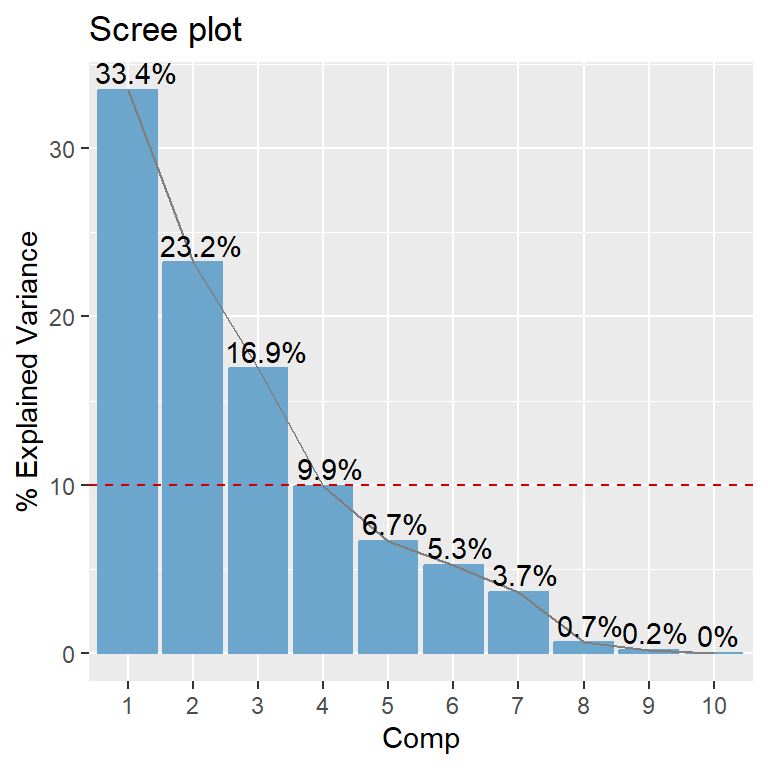

```r
pcaPlot(mipca, type = 'scree')
```

```r
K = 4
kable(mipca$explVar[1:K,])
```

| comp | eigenVal | percVar | cumPercVar |
| --- | --- | --- | --- |
| 1 | 3.3435597 | 33.4356 | 33.4356 |
| 2 | 2.3212806 | 23.2128 | 56.6484 |
| 3 | 1.6910210 | 16.9102 | 73.5586 |
| 4 | 0.9938463 | 9.9385 | 83.4971 |

Si optamos por el criterio de escoger aquellas PCs que expliquen más varianza que la “media” (línea roja en el gráfico, que indica la varianza explicada por cada PC si todas explicaran lo mismo), elegiríamos 3 PCs, aunque la PC 4 se quedaría fuera por poco. Como el criterio del codo nos apunta quizás a 4 PCs, nos quedaremos inicialmente con este número de PCs, que explican un 83.5% de la varianza total de los datos.

Haremos ahora una exploración rápida de las PCs seleccionadas para confirmar que todo ha funcionado bien y para indagar si prescindimos de alguna de las PCs porque no nos aporta información relevante para nuestro objetivo en este estudio: entender la relación entre el *rating* y las variables nutricionales de los cereales.

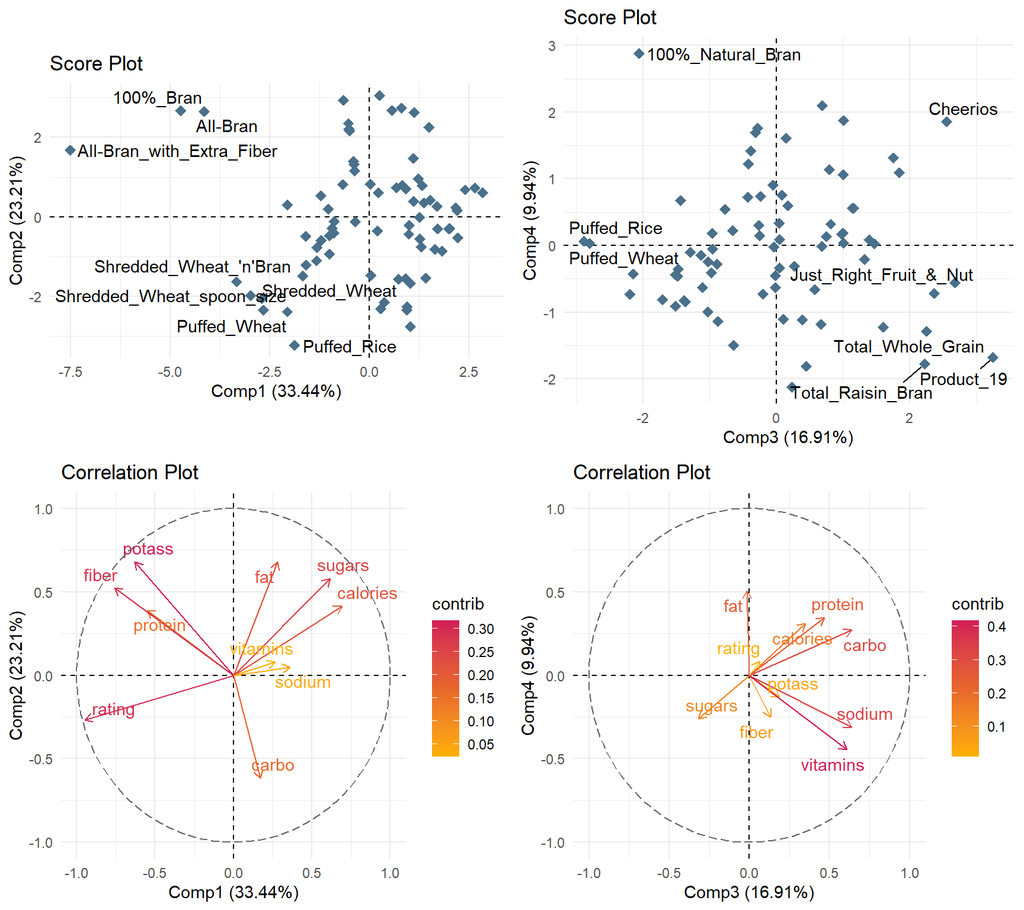

```r
p1 = pcaPlot(mipca, type = 'scores', comp = 1:2, colBy = NULL, labels = TRUE,
             labelTop = 0.1, repel = TRUE)
p2 = pcaPlot(mipca, type = 'scores', comp = 3:4, colBy = NULL, labels = TRUE,
             labelTop = 0.1, repel = TRUE)
p3 = pcaPlot(mipca, type = 'corr', comp = 1:2, colBy = "contrib",
             labels = TRUE, repel = TRUE, col = "hot")
p4 = pcaPlot(mipca, type = 'corr', comp = 3:4, colBy = "contrib",
             labels = TRUE, repel = TRUE, col = "hot")
grid.arrange(p1,p2,p3,p4, nrow = 2)
```

En las 2 primeras PCs ya observamos 3 cereales un poco más alejados que el resto. Veremos más adelante si se pueden considerar anómalos y qué hacemos con ellos.

Por otra parte, si nuestro objetivo es estudiar la relación del *rating* de los cereales con el resto de variables, podemos descartar las PC3 y PC4, ya que *rating* está mal representado en dichas PCs. Por tanto, generamos un nuevo modelo PCA con 2 PCs.

```r
K = 2
mipca = pca(cerePCA, ncomp = K,
            algo = "nipals", scaling = "standard")
```

# 3 Validación del modelo PCA

## 3.1 Detección de anómalos moderados con la distancia al modelo (SCR)

Estudiaremos la distancia al modelo PCA mediante la Suma de Cuadrados Residual (SCR), que nos ayudará a detectar los valores anómalos moderados, es decir, aquellas observaciones (cereales) que no están bien explicadas por el modelo PCA.

```r
par(mfrow = c(1,2))
anomSCR95 = pcaOutliers(mipca, method = "RSS", conf = 95)
anomSCR99 = pcaOutliers(mipca, method = "RSS", conf = 99)
```

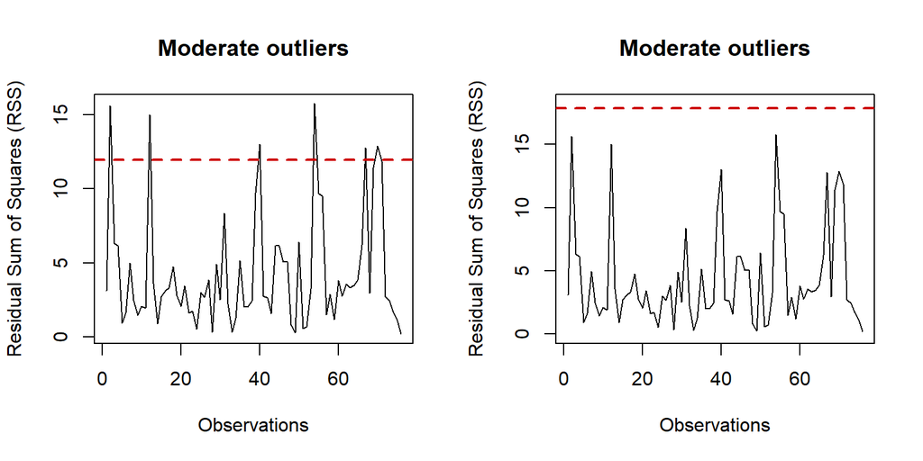

Para un nivel de confianza del 95%, tenemos los siguientes cereales anómalos (moderados):

```r
moderados = sort(anomSCR95$RSS[anomSCR95$ModerateOutliers], decreasing = TRUE)
moderados
```

```
##             Product_19      100%_Natural_Bran               Cheerios
##               15.74715               15.61107               15.00867
## Just_Right_Fruit_&_Nut      Total_Raisin_Bran              Special_K
##               12.99961               12.88271               12.75752
```

En este caso, hay 6 cereales que se salen fuera del límite del 95%, y 0 fuera del límite del 99%. Dado que, para el 95%, el número de posibles falsas alarmas es 3.8, veamos qué variables contribuyen más a las anomalías de los cereales con mayor SCR: Product_19, 100%_Natural_Bran, Cheerios.

```r
par(mfrow = c(1,3))
outlierContrib(mipca, outliers = anomSCR95, specificObs = names(moderados[1:3]))
```

```
## There are no severe outliers in the data or they were not computed.
## There are 3 moderate outliers in the data provided.
```

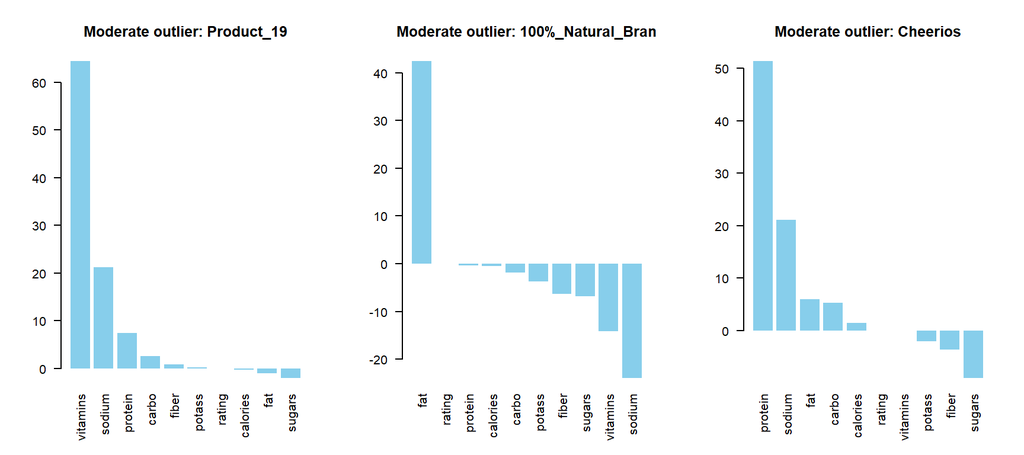

```
## $contribT2
## NULL
##
## $contribRSS
##                     calories    protein       fat    sodium      fiber
## Product_19        -0.2713136  7.3928920 -1.063686  21.21671  0.8349335
## 100%_Natural_Bran -0.4548144 -0.3863246 42.368997 -23.96434 -6.3747457
## Cheerios           1.4654122 51.3173525  5.959422  21.11531 -3.6829246
##                       carbo    sugars     potass      vitamins      rating
## Product_19         2.510940 -2.066980  0.2410093  64.395347248 0.006187299
## 100%_Natural_Bran -1.796547 -6.792046 -3.6776721 -14.158564255 0.025949793
## Cheerios           5.258920 -9.097377 -2.0882505  -0.001294152 0.013739226
```

Para verificar qué está pasando con las variables “causantes” de las anomalías de estos cereales, vamos a representar un diagrama de cajas y bigotes de las variables escaladas y veremos dónde se sitúan nuestros cereales anómalos:

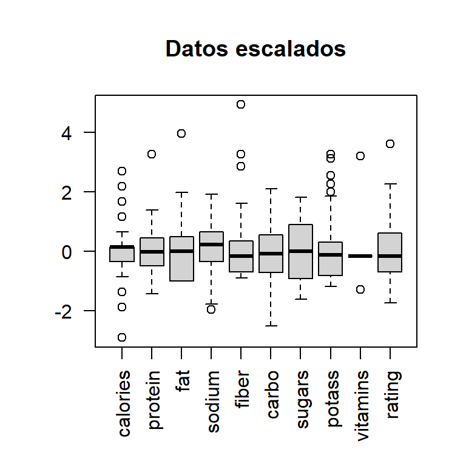

```r
boxplot(mipca$X, las = 2, main = "Datos escalados")
```

```r
kable(round(mipca$X[names(moderados[1:3]),],2))
```

|  | calories | protein | fat | sodium | fiber | carbo | sugars | potass | vitamins | rating |
| --- | --- | --- | --- | --- | --- | --- | --- | --- | --- | --- |
| Product_19 | -0.36 | 0.46 | -0.99 | 1.92 | -0.48 | 1.33 | -0.92 | -0.76 | 3.21 | -0.07 |
| 100%_Natural_Bran | 0.66 | 0.46 | 3.97 | -1.78 | -0.06 | -1.74 | 0.22 | 0.51 | -1.29 | -0.61 |
| Cheerios | 0.15 | 3.28 | 0.99 | 1.56 | -0.06 | 0.56 | -1.38 | 0.09 | -0.16 | 0.58 |

Por ejemplo, vimos en los gráficos de contribuciones que el cereal “Product_19” tiene un valor anormalmente alto en la variable *vitamins*, en concreto 3.21. Este caso concreto no nos preocupa porque la variable *vitamins* solo toma 3 valores en nuestra base de datos y este cereal está tomando el valor más alto, pero no lo consideraremos anómalo ni se trata de un error.

```r
table(cerePCA$vitamins)
```

```
##
##   0  25 100
##   7  63   6
```

Si nos fijamos en el cereal “100%_Natural_Bran”, el gráfico de contribuciones a la SCR indica que tiene un valor anormalmente alto en *fat* y algo bajo en *sodium*. Este último no es preocupante pero, en cambio, sí destaca el valor alto de *fat* que, de nuevo, toma solo unos pocos valores discretos, como se observa en la siguiente tabla. Una posible solución para esta variable, dado que no parece que se trate de un error, sería aplicar una transformación logarítmica para suavizar la influencia del valor anómalo.

```r
table(cerePCA$fat)
```

```
##
##  0  1  2  3  5
## 27 30 13  5  1
```

Finalmente, el cereal “Cheerios” presenta un valor muy alto en la variable *protein*, causado de nuevo por la naturaleza discreta de esta variable, que también podría beneficiarse de una transformación logarítmica.

```r
table(cerePCA$protein)
```

```
##
##  1  2  3  4  6
## 13 25 28  8  2
```

## 3.2 Detección de anómalos severos con T2-Hotelling

El estadístico $T^2$ de Hotelling nos permite identificar valores anómalos severos, que podrían estar condicionando el modelo, es decir, la creación de las PCs. Recordemos que los anómalos severos son aquellos detectados con el gráfico $T^2$ de Hotelling y que además presentan una baja SCR.

```r
par(mfrow = c(1,2))
anomSev95 = pcaOutliers(mipca, method = "T2", conf = 95)
anomSev99 = pcaOutliers(mipca, method = "T2", conf = 99)
```

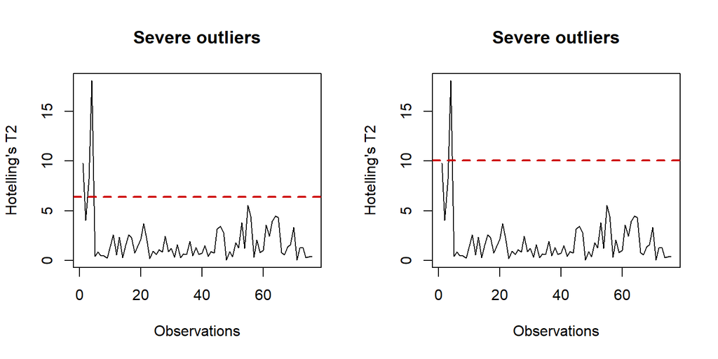

```r
anomSev95$T2[anomSev95$SevereOutliers]
```

```
##                 100%_Bran                  All-Bran All-Bran_with_Extra_Fiber
##                  9.781243                  8.163422                 18.068008
```

Nos preocupa especialmente el cereal All-Bran_with_Extra_Fiber por su alto valor del estadístico $T^2$-Hotelling, que se aleja bastante del límite de confianza y no lo detectamos como anómalo moderado con la SCR. Veamos su gráfico de contribución:

```r
outlierContrib(mipca, outliers = anomSev99)
```

```
## There are 1 severe outliers in the data provided.
```

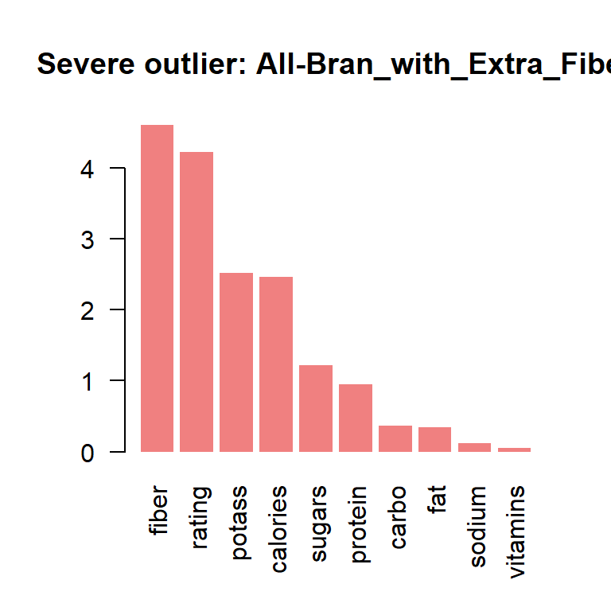

```
## There are no moderate outliers in the data or they were not computed.
```

```
## $contribT2
##                           calories   protein       fat    sodium    fiber
## All-Bran_with_Extra_Fiber 2.467494 0.9462641 0.3442091 0.1175482 4.606775
##                               carbo   sugars   potass   vitamins   rating
## All-Bran_with_Extra_Fiber 0.3648043 1.214444 2.521178 0.05324373 4.222943
##
## $contribRSS
## NULL
```

```r
mipca$X[anomSev99$SevereOutliers,]
```

```
##   calories    protein        fat     sodium      fiber      carbo     sugars
## -2.9072269  1.3967531 -0.9933993 -0.2645217  4.9430817 -1.7409943 -1.6046739
##     potass   vitamins     rating
##  3.2659536 -0.1626251  3.6251656
```

Este cereal presenta valores extremos en *fiber* y *rating*. Dado que ambas variables presentan valores anormalmente altos, podrían beneficiarse de una transformación logarítmica para suavizar su influencia en futuros análisis.

*EJERCICIO 2*

*¿Se te ocurre una forma alternativa a los gráficos de contribuciones para averiguar qué variable o variables son las “culpables”, es decir, contribuyen más a que un determinado cereal sea declarado anómalo severo?*

## 3.3 Modelo PCA tras los ajustes derivados de la detección de anómalos

En este estudio no eliminaremos anómalos pero vamos a transformar logarítmicamente las variables identificadas como influyentes en la detección de anómalos: *fiber*, *rating*, *protein* y *fat*, y recalculamos el modelo PCA.

```r
var2transf = c("fiber", "rating", "protein", "fat")
for (v in var2transf) {
  if (min(cerePCA[,v], na.rm = TRUE) == 0) {
    cerePCA[,v] = log(cerePCA[,v]+1)
  }
  if (min(cerePCA[,v], na.rm = TRUE) > 0) {
    cerePCA[,v] = log(cerePCA[,v])
  }
  if (min(cerePCA[,v], na.rm = TRUE) < 0) {
    cerePCA[,v] = log(cerePCA[,v]-min(cerePCA[,v], na.rm = TRUE)+1)
  }
}
```

```r
K = 2
mipca = pca(cerePCA, ncomp = K,
            algo = "nipals", scaling = "standard")
kable(mipca$explVar[1:K,])
```

| comp | eigenVal | percVar | cumPercVar |
| --- | --- | --- | --- |
| 1 | 3.323189 | 33.2319 | 33.2319 |
| 2 | 2.397289 | 23.9729 | 57.2048 |

*EJERCICIO 3*

*Verificar cuántas PCs se deberían seleccionar a partir del scree plot y cuántas son realmente necesarias para estudiar el rating de los cereales.*

*EJERCICIO 4*

*A partir de este nuevo PCA, comprobar si se siguen detectando anómalos moderados o severos. ¿Qué decisiones tomarías?*

# 4 Interpretación del modelo PCA

Procederemos a interpretar el nuevo modelo PCA obtenido.

```r
fabricante = cereals[rownames(cerePCA), "mfr"]
table(fabricante)
```

```
## fabricante
##  A  G  K  N  P  Q  R
##  1 22 23  6  9  7  8
```

```r
fabricante = factor(fabricante, labels = c("O", "G", "K", "O", "P", "O", "R"))
table(fabricante)
```

```
## fabricante
##  O  G  K  P  R
## 14 22 23  9  8
```

## 4.1 Score plot y gráficos de variables

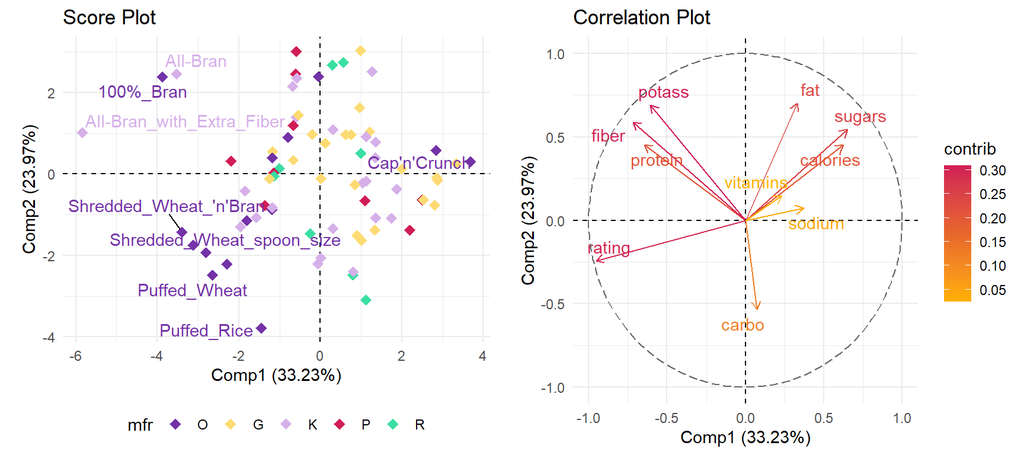

```r
p1 = pcaPlot(mipca, type = 'scores', comp = 1:2,
             colBy = data.frame("mfr" = fabricante),
             labels = TRUE, ellipses = FALSE, repel = TRUE, labelTop = 0.1)
p2 = pcaPlot(mipca, type = 'corr', comp = 1:2, colBy = "contrib",
             labels = TRUE, repel = TRUE, col = "hot")
grid.arrange(p1,p2, nrow = 1)
```

Observamos en el gráfico de scores que la principal agrupación de los cereales no es por el fabricante, ya que los cereales de los distintos fabricantes están mezclados entre sí.

En cuanto a las variables, parece que hay cierta correlación positiva entre *protein*, *fiber* y *potass*, así como entre *calories* y *sugar*, mientras que el *rating* se correlaciona negativamente con estas dos últimas. Dado que el *rating* tiene contribuye principalmente a la PC1, vemos que otras variables con gran peso en esta componente y con el mismo signo de loading son *fiber* y *protein*, por lo que también tendrán cierta relación con el *rating*.

Si combinamos ambos gráficos y nos fijamos en *rating*, parece ser que el cereal “All-Bran-with-Extra-Fiber” será el que tenga mayor rating, mientras que “Cap’n’Crunch” serán el cereal con menor rating. Confirmemos esta afirmación:

```r
ordenRating = cerePCA[order(cerePCA$rating, decreasing = TRUE), "rating", drop = FALSE]
ordenRating[1:3,,drop = FALSE]
```

```
##                             rating
## All-Bran_with_Extra_Fiber 4.540151
## Shredded_Wheat_'n'Bran    4.310436
## Shredded_Wheat_spoon_size 4.287741
```

```r
ordenRating[nrow(cerePCA),,drop = FALSE]
```

```
##               rating
## Cap'n'Crunch 2.89275
```

También podemos observar que los cereales con mayor cantidad de fibra y potasio serán “All-bran” y “100%_Bran”, o que “Puffed_Rice” tendrá alto contenido en carbohidratos.

A continuación, generamos gráficos de dispersión para confirmar las hipótesis sobre las relaciones entre variables sugeridas por el PCA:

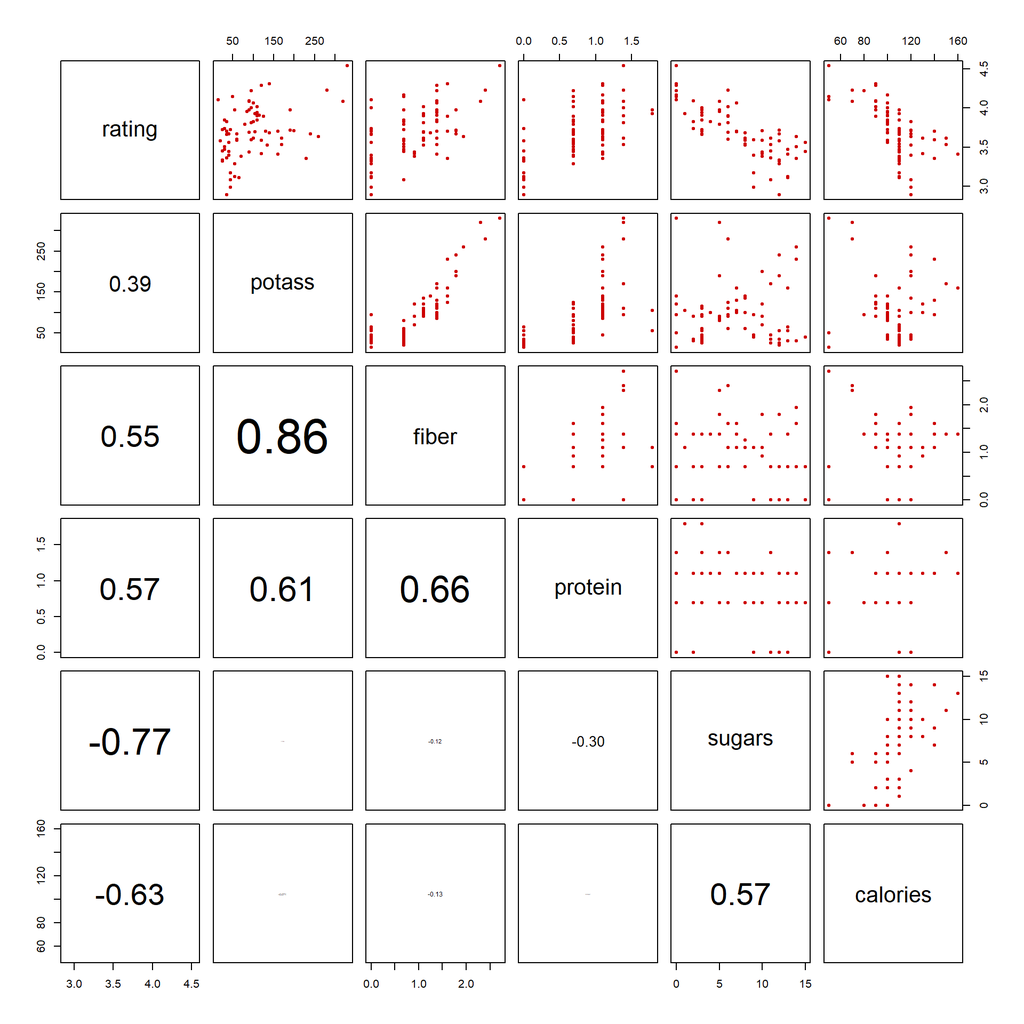

```r
panel.cor <- function(x, y, digits = 2, prefix = "", cex.cor, ...)
{
    par(usr = c(0, 1, 0, 1))
    r <- cor(x, y, use = "pairwise.complete.obs")
    txt <- format(c(r, 0.123456789), digits = digits)[1]
    txt <- paste0(prefix, txt)
    if(missing(cex.cor)) cex.cor <- 0.8/strwidth(txt)
    text(0.5, 0.5, txt, cex = cex.cor * abs(r))
}
pairs(cerePCA[,c("rating", "potass", "fiber", "protein", "sugars", "calories")],
      lower.panel = panel.cor, pch = 20, col = "red3")
```

*EJERCICIO 5*

*A la vista de estos gráficos y correlaciones, ¿se podrían considerar válidas las afirmaciones que hemos hecho al interpretar el gráfico de variables del PCA?*

**NOTA IMPORTANTE:** No es obligatorio hacer siempre las comprobaciones anteriores. Las hemos hecho para ayudar a entender mejor la interpretación del PCA. No obstante, nunca está de más generar aquellos gráficos que consideréis necesarios para ilustrar las conclusiones extraídas del PCA acerca de la relación entre variables, o entre variables y observaciones, y corroborarlas.

*EJERCICIO 6*

*Genera el gráfico de LOADINGS para las dos primeras componentes principales y compáralo con el gráfico de correlación de variables obtenido anteriormente. ¿Qué diferencias observas y a qué se deben?*

## 4.2 Gráfico $R^2$

El siguiente gráfico muestra el porcentaje de variabilidad de cada variable ($k$) que queda explicado por el modelo PCA ($R^2_k(cum)$). ¿Qué variable está mejor explicada por el modelo PCA?*

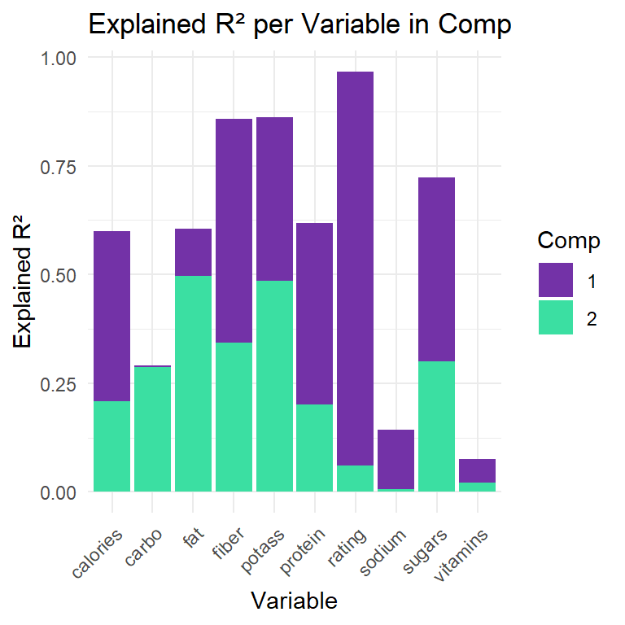

```r
pcaPlot(mipca, type = "R2")
```

*EJERCICIO 7*

*¿Qué conclusiones obtienes a partir del gráfico anterior? ¿Coinciden con lo que habías observado en gráficos anteriores?*

## 4.3 Biplot

En ocasiones es útil representar en el mismo gráfico las variables y las observaciones, para mejorar la interpretación. No obstante, hay que afinar en la forma de representar estos gráficos porque si tenemos muchas observaciones y/o variables es posible que no sea la mejor opción porque quizás no se visualice bien lo que queremos mostrar.

En este caso, no mostraremos el nombre de los cereales, solo el de las variables, excluyendo las dos peor representadas en las dos primeras PCs, y colorearemos los cereales según la estantería en la que se colocan en el supermercado.

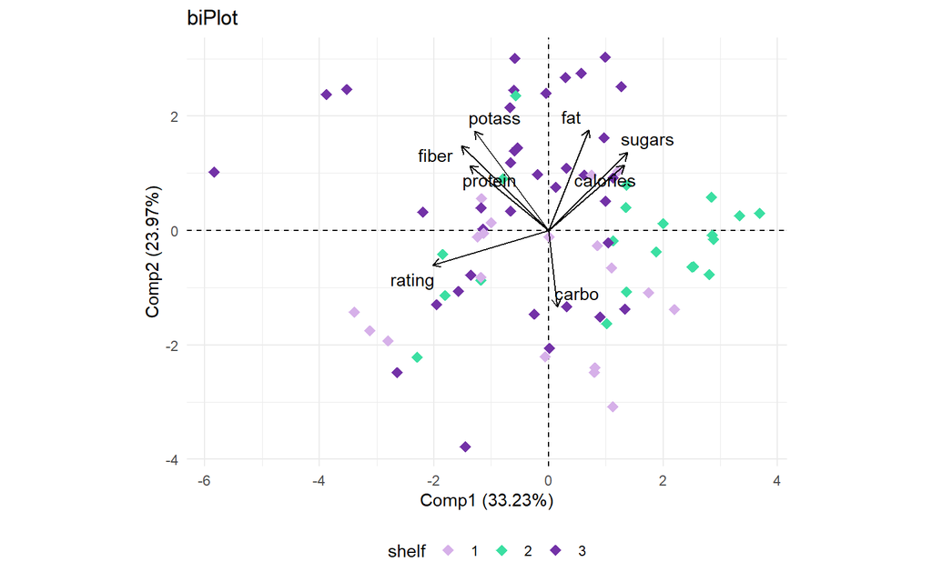

```r
estante = factor(cereals[rownames(cerePCA), "shelf"])
pcaPlot(mipca, type = 'biplot', comp = 1:2,
        colBy = data.frame("shelf" = estante), selVars = 0.8, repel = TRUE)
```

*EJERCICIO 8*

*¿Podrías caracterizar a los cereales que se colocan en cada estantería a partir del gráfico anterior?*

**NOTA IMPORTANTE**

En esta práctica guiada se han mostrado distintas gráficas generadas a partir del modelo PCA y con distintas opciones de representación, coloreado, etiquetado, etc. No todas las gráficas son igual de explicativas o útiles en todos los análisis PCA. Dependiendo de las características de la BBDD a analizar, se deben elegir las gráficas y opciones más apropiadas, que ayuden a interpretar y visualizar mejor los resultados.